# Nonparametric Smoothing: Moving Beyond Linearity

# 1 **mcycle** motorcycle accident dataset

`mcycle` is a data frame giving a series of measurements of head acceleration in a simulated motorcycle accident, used to test crash helmets. It is an univariate case. We are interested in the relationship between the times in milliseconds after impact and the acceleration.

```r
library(MASS)
data('mcycle')
str(mcycle)
summary(mcycle)
```

[output not shown]

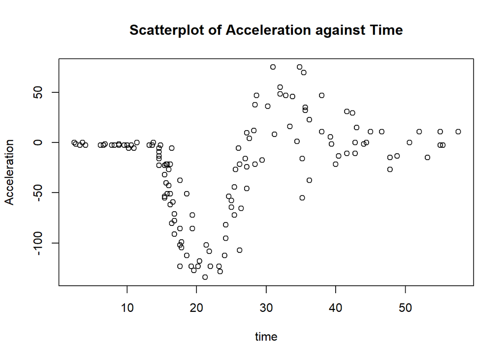

```r
# Rename the variables for ease of usage
Y <- mcycle$accel
X <- mcycle$times

#Scatterplot
plot(Y~X, xlab="time",ylab="Acceleration", main="Scatterplot of Acceleration against Time")
```

# 2 Simple Linear Regression

We can simply assume a linear relationship and run a linear model between acceleration and time.

```r
lm_mod <- lm(Y~X, data= mcycle)
summary(lm_mod)
```

[output not shown]

**Fitted Regression Line**

But after we draw the fitted linear line on the scatterplot, we can clearly tell that the linear assumption seems violated.

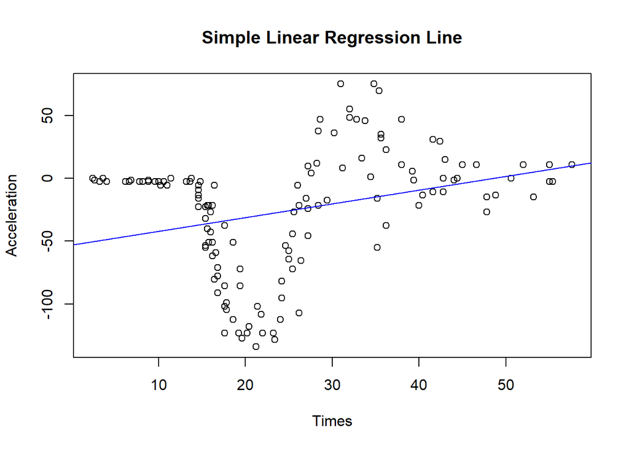

```r
plot(X, Y, xlab="Times", ylab="Acceleration", main="Simple Linear Regression Line")
abline(lm_mod, col="blue", lwd = 1)
```

# 3 Polynomial Regression

If we assume there could be a polynomial relationship, we can try polynomial regression. The coefficients can be easily estimated using least squares linear regression because this is just a standard linear model with predictors $x, x^2, x^3, \dots, x^d$.

## 3.1 Quadratic

We can conduct a quadratic regression as follows by simply adding `I(X^2)` in the formula argument:

```r
quad_mod <- lm(Y~X+I(X^2), data=mcycle)
summary(quad_mod)
```

```
##
## Call:
## lm(formula = Y ~ X + I(X^2), data = mcycle)
##
## Residuals:
##     Min      1Q  Median      3Q     Max
## -96.527 -30.817   9.589  29.210 104.728
##
## Coefficients:
##              Estimate Std. Error t value Pr(>|t|)
## (Intercept) -15.22700   15.49471  -0.983  0.32757
## X            -2.30749    1.20439  -1.916  0.05757 .
## I(X^2)        0.05935    0.02038   2.912  0.00422 **
## ---
## Signif. codes:  0 '***' 0.001 '**' 0.01 '*' 0.05 '.' 0.1 ' ' 1
##
## Residual standard error: 45.06 on 130 degrees of freedom
## Multiple R-squared:  0.1437, Adjusted R-squared:  0.1306
## F-statistic: 10.91 on 2 and 130 DF,  p-value: 4.167e-05
```

It seems that the fitted line captures the curvature a little bit better than the linear regression.

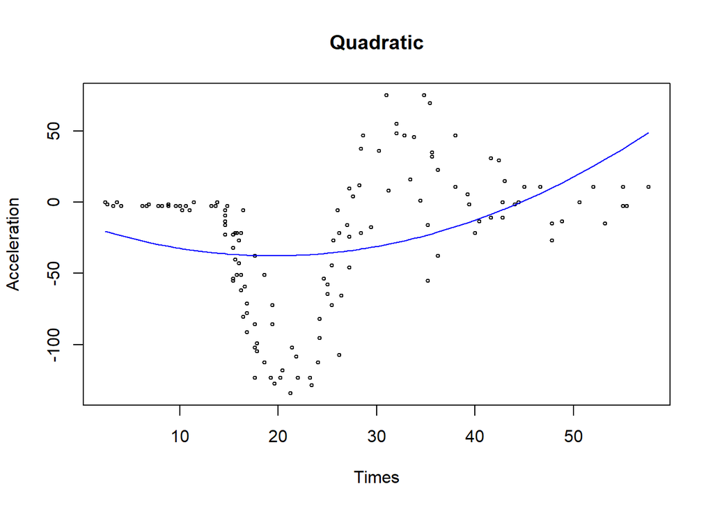

```r
plot(X ,Y ,xlab="Times", main = "Quadratic",ylab="Acceleration",cex=.5)
lines(X,quad_mod$fitted.values, col="blue", lwd = 1)
```

**Is this model superior to the simple linear regression model?**

In order to answer this question, we can conduct the ANOVA test to compare the fits of these two models.

```r
anova(lm_mod,quad_mod)
```

|  | Res.Df | RSS | Df | Sum of Sq | F | Pr(>F) |
| --- | --- | --- | --- | --- | --- | --- |
| 1 | 131 | 281143.8 | NA | NA | NA | NA |
| 2 | 130 | 263923.3 | 1 | 17220.56 | 8.482288 | 0.004222279 |

## 3.2 Fifth-degree Polynomial

We can also try higher order polynomial regress, for example a fifth-degree polynomial.

```r
poly_mod <- lm(Y~poly(X,5,raw=T),data=mcycle)
summary(poly_mod)
```

```
##
## Call:
## lm(formula = Y ~ poly(X, 5, raw = T), data = mcycle)
##
## Residuals:
##     Min      1Q  Median      3Q     Max
## -77.271 -21.285   0.975  25.386  82.371
##
## Coefficients:
##                        Estimate Std. Error t value Pr(>|t|)
## (Intercept)          -1.059e+02  3.499e+01  -3.026    0.003 **
## poly(X, 5, raw = T)1  4.978e+01  1.036e+01   4.804 4.31e-06 ***
## poly(X, 5, raw = T)2 -6.359e+00  1.015e+00  -6.266 5.30e-09 ***
## poly(X, 5, raw = T)3  2.969e-01  4.253e-02   6.982 1.45e-10 ***
## poly(X, 5, raw = T)4 -5.742e-03  7.932e-04  -7.239 3.83e-11 ***
## poly(X, 5, raw = T)5  3.919e-05  5.406e-06   7.250 3.60e-11 ***
## ---
## Signif. codes:  0 '***' 0.001 '**' 0.01 '*' 0.05 '.' 0.1 ' ' 1
##
## Residual standard error: 33.9 on 127 degrees of freedom
## Multiple R-squared:  0.5264, Adjusted R-squared:  0.5078
## F-statistic: 28.24 on 5 and 127 DF,  p-value: < 2.2e-16
```

You can also assess the model performance.

```r
#poly_mod_summary <- summary(poly_mod)
#(poly_mod_summary$sigma)^2
#poly_mod_summary$r.squared
#poly_mod_summary$adj.r.squared
#AIC(poly_mod)
#BIC(poly_mod)
```

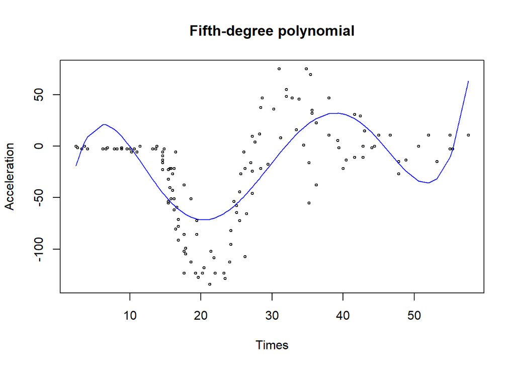

```r
plot(X ,Y ,xlab="Times", main = "Fifth-degree polynomial",ylab="Acceleration",cex=.5)
lines(X,poly_mod$fitted.values, col="blue", lwd = 1)
```

This one may be even better to capture the curvature of samples on the left hand side of scatter plot than those two model above.

go to top

# 4 Splines

## 4.1 Regression Splines

In order to fit regression splines in R, we use the `bs()` function from the splines library. By default, “cubic splines” are produced. That is cubic polynomial with no interior knots

```r
library (splines)
reg_sp <- lm(Y~bs(X),data=mcycle)
summary(reg_sp)
```

```
##
## Call:
## lm(formula = Y ~ bs(X), data = mcycle)
##
## Residuals:
##     Min      1Q  Median      3Q     Max
## -83.083 -28.772   2.935  31.004  94.108
##
## Coefficients:
##             Estimate Std. Error t value Pr(>|t|)
## (Intercept)    41.26      15.42   2.675 0.008433 **
## bs(X)1       -258.14      41.07  -6.285 4.66e-09 ***
## bs(X)2        110.67      28.33   3.906 0.000151 ***
## bs(X)3        -72.91      27.99  -2.605 0.010274 *
## ---
## Signif. codes:  0 '***' 0.001 '**' 0.01 '*' 0.05 '.' 0.1 ' ' 1
##
## Residual standard error: 40 on 129 degrees of freedom
## Multiple R-squared:  0.3303, Adjusted R-squared:  0.3147
## F-statistic: 21.21 on 3 and 129 DF,  p-value: 3.134e-11
```

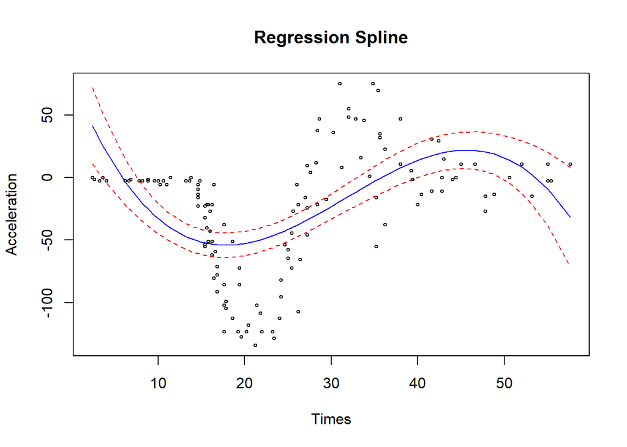

```r
plot(X ,Y ,xlab="Times", main = "Regression Spline",ylab="Acceleration",cex=.5)
lines(X,reg_sp$fitted.values, col="blue", lwd = 1)

conf_interval <- predict(reg_sp, interval="confidence",
                         level = 0.95)
lines(X, conf_interval[,2], col="red", lty=2)
lines(X, conf_interval[,3], col="red", lty=2)
```

You can also specify the knot locations.

```r
#fit_sp=lm(Y~bs(X,knots=c(15.6,23.4,34.8)),data=mcycle)
#summary(fit_sp)
#AIC(fit_sp)
```

You can also specify the degree of freedom.

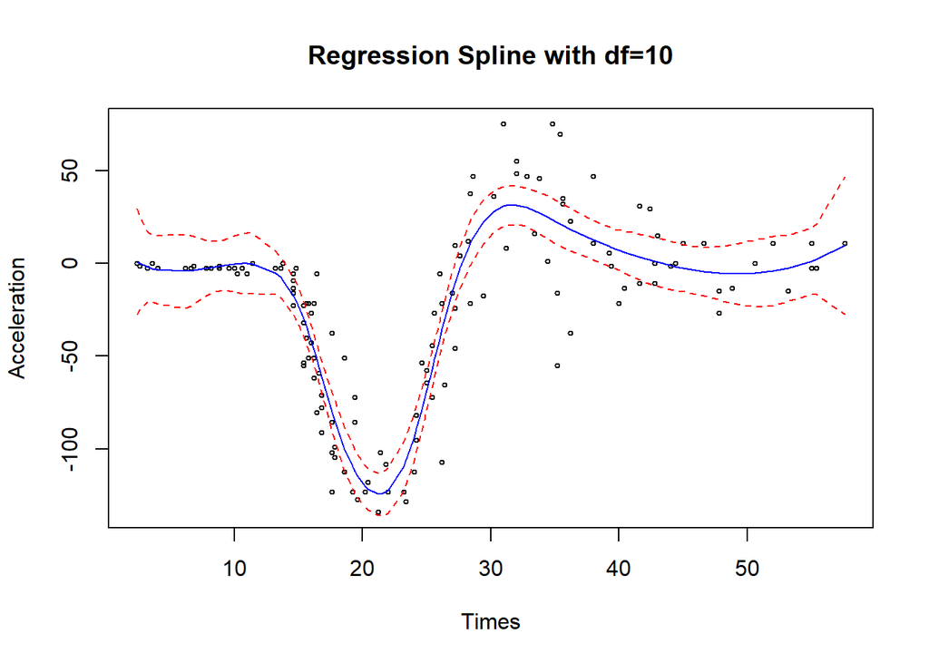

```r
reg_sp2=lm(Y~bs(X,df=10),data=mcycle)

plot(X ,Y ,xlab="Times", main = "Regression Spline with df=10",ylab="Acceleration",cex=.5)
lines(X,reg_sp2$fitted.values, col="blue", lwd = 1)

conf_interval <- predict(reg_sp2, interval="confidence",
                         level = 0.95)
lines(X, conf_interval[,2], col="red", lty=2)
lines(X, conf_interval[,3], col="red", lty=2)
```

## 4.2 Natural Cubic Splines

Here the degree of freedom is pre-specified and different numbers are used to see the best curve that fits the data.

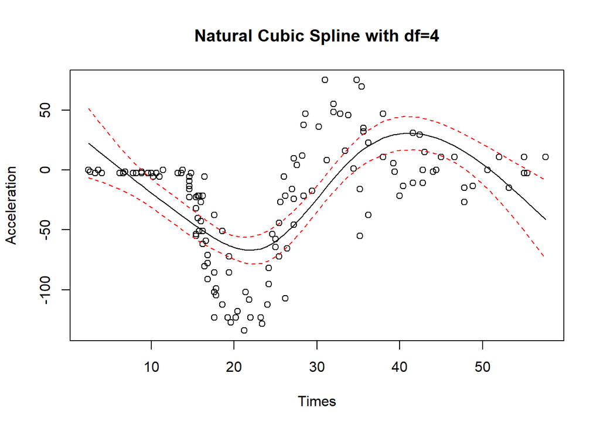

```r
#First: Natural Spline- pre-specified degree of freedom=4
fit2=lm(Y~ns(X,df=4),data=mcycle)
plot(X ,Y,main= "Natural Cubic Spline with df=4", xlab="Times", ylab="Acceleration")
lines(X, fit2$fitted.values)

conf_interval <- predict(fit2, interval="confidence",
                         level = 0.95)
lines(X, conf_interval[,2], col="red", lty=2)
lines(X, conf_interval[,3], col="red", lty=2)
```

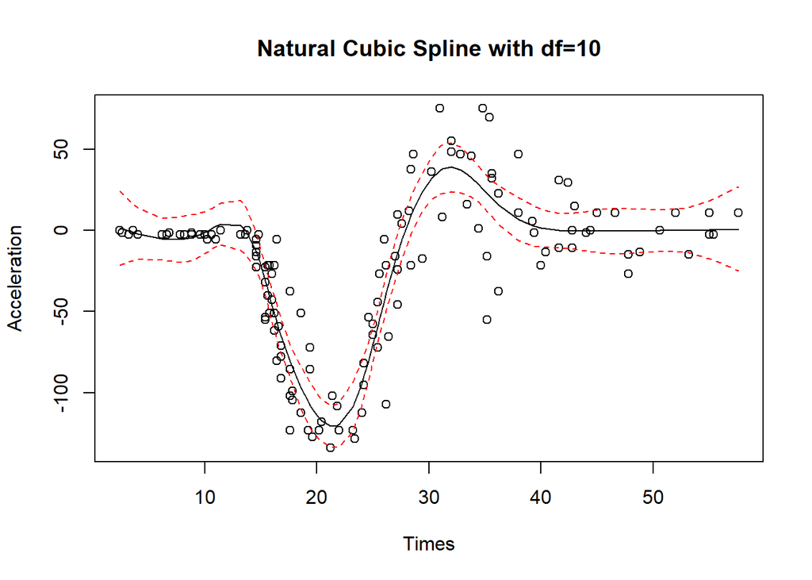

```r
fit2c=lm(Y~ns(X,df=10),data=mcycle)

plot(X ,Y , main= "Natural Cubic Spline with df=10", xlab="Times", ylab="Acceleration")
lines(X, fit2c$fitted.values)

conf_interval <- predict(fit2c, interval="confidence",
                         level = 0.95)
lines(X, conf_interval[,2], col="red", lty=2)
lines(X, conf_interval[,3], col="red", lty=2)
```

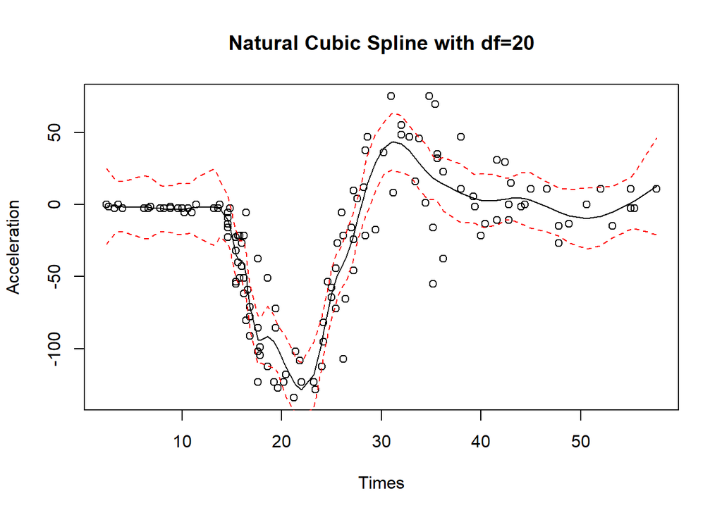

```r
fit2d=lm(Y~ns(X,df=20),data=mcycle)

plot(X ,Y, main= "Natural Cubic Spline with df=20", xlab="Times", ylab="Acceleration")
lines(X, fit2d$fitted.values)

conf_interval <- predict(fit2d, interval="confidence",
                         level = 0.95)
lines(X, conf_interval[,2], col="red", lty=2)
lines(X, conf_interval[,3], col="red", lty=2)
```

## 4.3 Smoothing/Penalized Spline

We now use penalized splines where a penalty/smoothing parameter can help control the smoothness while many knots can be used and knot location does not need to be carefully selected. The `s()` function is part of the gam function from the mgcv package.

go to top